# Lesson 5

```r
library(ggplot2)
library(tidyr)
library(dplyr)
setwd("C:/Users/Christopher/Desktop/Nanodegree/P4-EDA/eda-course-materials")

pf <- read.csv("pseudo_facebook.tsv", header = T, sep = "\t")
```

### Multivariate Data

Notes:

### Moira Perceived Audience Size Colored by Age

Notes:

### Third Qualitative Variable

Notes:

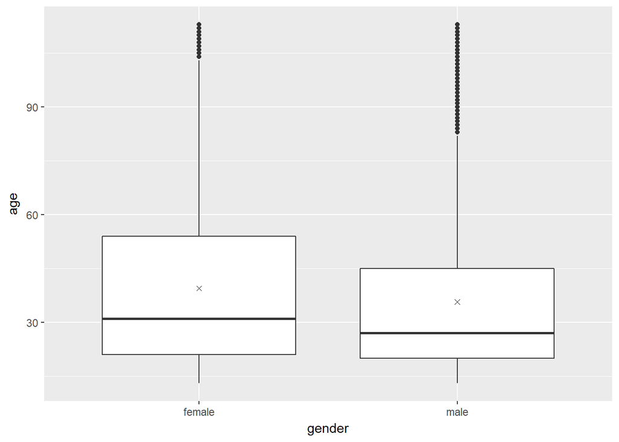

```r
ggplot(aes(x = gender, y = age),
       data = subset(pf, !is.na(gender))) +
  geom_boxplot() + stat_summary(fun.y = mean, geom = 'point', shape=4)
```

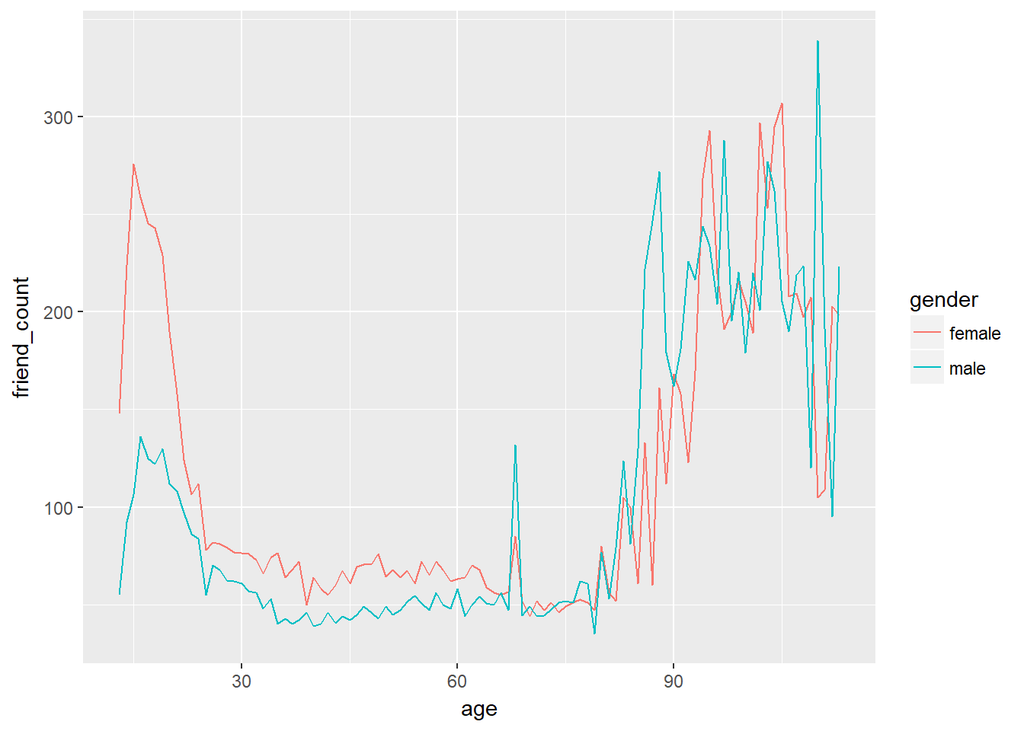

```r
ggplot(aes(x = age, y = friend_count),
       data = subset(pf, !is.na(gender))) +
  geom_line(aes(color=gender), stat = "summary", fun.y = median)
```

### Plotting Conditional Summaries

Notes:

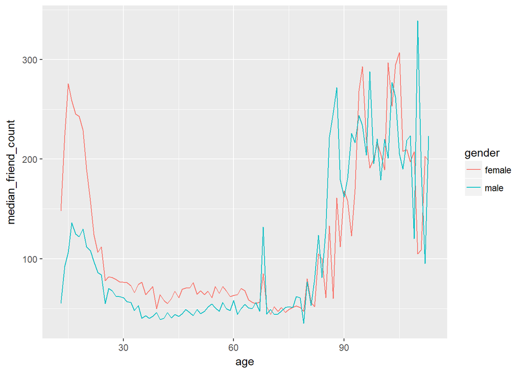

```r
pf.fc_by_age_gender <- group_by(pf, age, gender) %>%
  summarize(mean_friend_count = mean(friend_count),
            median_friend_count = median(friend_count),
            n = n())

ggplot(aes(x = age, y = median_friend_count),
       data = subset(pf.fc_by_age_gender, !is.na(gender))) +
  geom_line(aes(color=gender))
```

### Thinking in Ratios

Notes:

### Wide and Long Format

Notes: If long includes repeated and discrete variables like age or gender, it is useful at times to create new dfs that aggregate these data with calculated parameters like median or mean. Categorical variables like gender are simply counted up in the wide format. ***

### Reshaping Data

Notes:

```r
library(reshape2)
pf.fc_by_age_gender.wide <- dcast(data = pf.fc_by_age_gender,
                                  age ~ gender,
                                  value.var = "median_friend_count")
pf.fc_by_age_gender.wide$ratio <-
  pf.fc_by_age_gender.wide$male/pf.fc_by_age_gender.wide$female
```

```r
pf.fc_by_age_gender.wide <- subset(
  pf.fc_by_age_gender[c('age', 'gender', 'median_friend_count')],
  !is.na(gender)) %>%
  spread(gender, median_friend_count) %>%
  mutate(ratio = male / female)
```

### Ratio Plot

Notes: The linetype parameter can take the values 0-6: 0 = blank, 1 = solid, 2 = dashed 3 = dotted, 4 = dotdash, 5 = longdash 6 = twodash

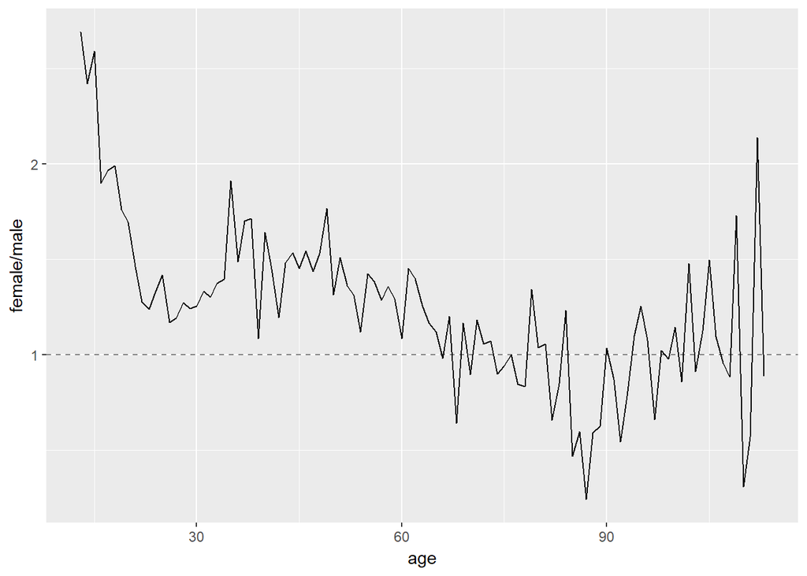

```r
ggplot(data = pf.fc_by_age_gender.wide, aes(x=age, y=female/male)) +
  geom_line() +
  geom_hline(yintercept = 1, linetype = 2, alpha=0.5)
```

### Third Quantitative Variable

Notes:

```r
pf$year_joined <- floor(2014-pf$tenure/365)
```

### Cut a Variable

Notes: Pretty pandas-like

```r
pf$year_joined.bucket <- cut(pf$year_joined, c(2004, 2009, 2011, 2012, 2014), labels = c("2004-2009", "2009-2011", "2011-2012", "2012-2014"))

table(pf$year_joined.bucket, useNA = "ifany")
```

```
##
## 2004-2009 2009-2011 2011-2012 2012-2014      <NA>
##      6669     15308     33366     43658         2
```

### Plotting it All Together

Notes:

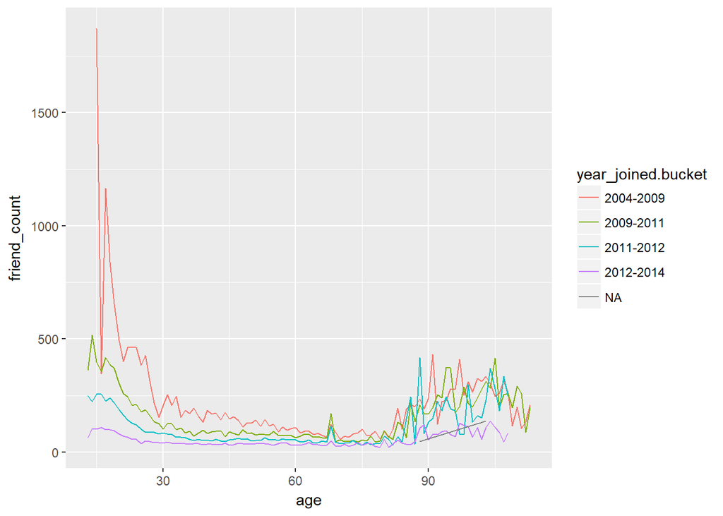

```r
ggplot(data = subset(pf, !is.na(gender)),
       aes(x=age, y=friend_count)) +
  geom_line(aes(color=year_joined.bucket), stat="summary",
            fun.y=median)
```

### Plot the Grand Mean

Notes:

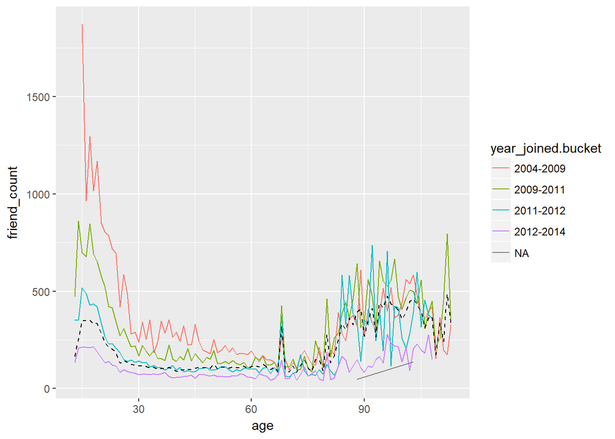

```r
ggplot(data = subset(pf, !is.na(gender) | !is.na(year_joined.bucket)),
       aes(x=age, y=friend_count)) +
  geom_line(aes(color=year_joined.bucket), stat="summary",
            fun.y=mean) +
  geom_line(stat="summary", fun.y=mean, linetype = 2)
```

### Friending Rate

Notes:

```r
with(subset(pf, tenure >0), summary(friend_count/tenure))
```

```
##     Min.  1st Qu.   Median     Mean  3rd Qu.     Max.
##   0.0000   0.0775   0.2205   0.6096   0.5658 417.0000
```

### Friendships Initiated

Notes:

What is the median friend rate?

What is the maximum friend rate?

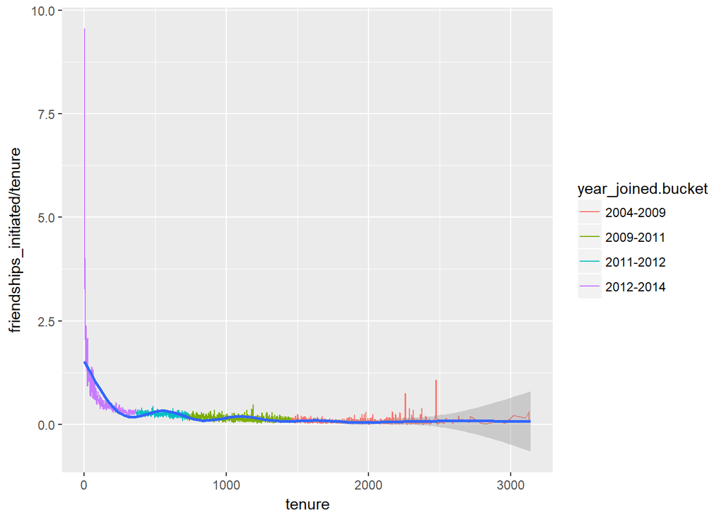

```r
ggplot(data=subset(pf, tenure > 0),
       aes(x = tenure,
           y = friendships_initiated/tenure)) + geom_line(aes(color=year_joined.bucket), stat="summary", fun.y=mean) +
  geom_smooth()
```

### Bias-Variance Tradeoff Revisited

Notes:

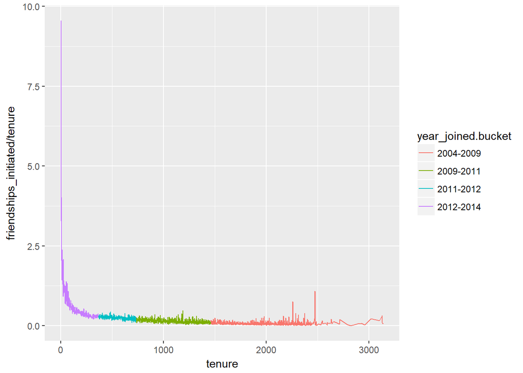

```r
ggplot(aes(x = tenure, y = friendships_initiated / tenure),
       data = subset(pf, tenure >= 1)) +
  geom_line(aes(color = year_joined.bucket),
            stat = 'summary',
            fun.y = mean)
```

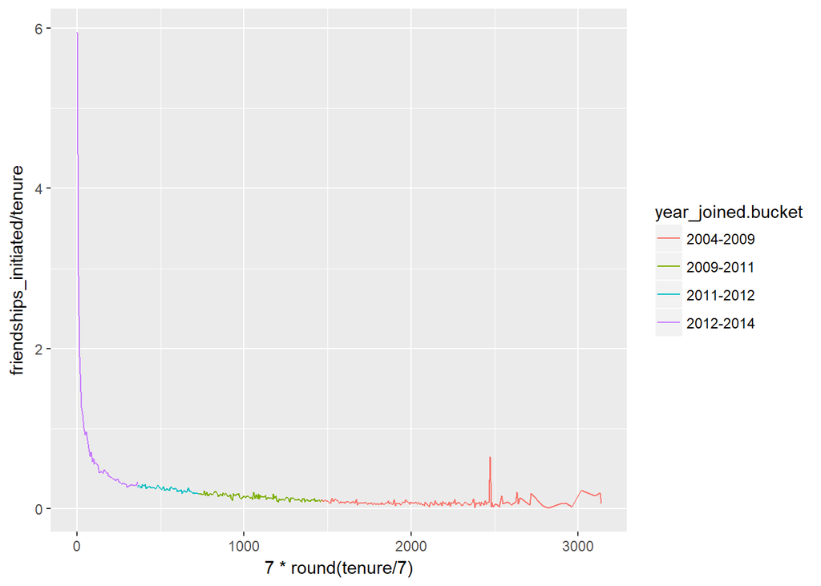

```r
ggplot(aes(x = 7 * round(tenure / 7), y = friendships_initiated / tenure),
       data = subset(pf, tenure > 0)) +
  geom_line(aes(color = year_joined.bucket),
            stat = "summary",
            fun.y = mean)
```

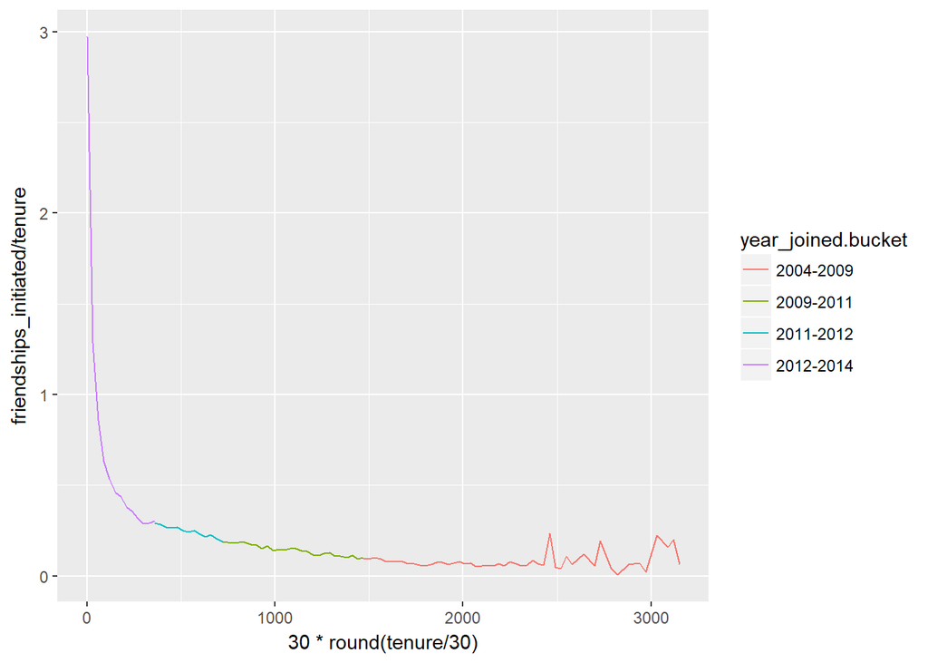

```r
ggplot(aes(x = 30 * round(tenure / 30), y = friendships_initiated / tenure),
       data = subset(pf, tenure > 0)) +
  geom_line(aes(color = year_joined.bucket),
            stat = "summary",
            fun.y = mean)
```

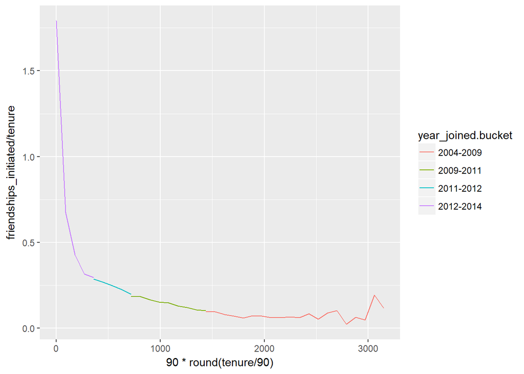

```r
ggplot(aes(x = 90 * round(tenure / 90), y = friendships_initiated / tenure),
       data = subset(pf, tenure > 0)) +
  geom_line(aes(color = year_joined.bucket),
            stat = "summary",
            fun.y = mean)
```

### Sean’s NFL Fan Sentiment Study

Notes:

### Introducing the Yogurt Data Set

Notes:

### Histograms Revisited

Notes:

```r
yo <- read.csv("yogurt.csv", header = T)
yo$id <- factor(yo$id)
str(yo)
```

```
## 'data.frame':    2380 obs. of  9 variables:
##  $ obs        : int  1 2 3 4 5 6 7 8 9 10 ...
##  $ id         : Factor w/ 332 levels "2100081","2100370",..: 1 1 1 1 1 1 1 1 1 1 ...
##  $ time       : int  9678 9697 9825 9999 10015 10029 10036 10042 10083 10091 ...
##  $ strawberry : int  0 0 0 0 1 1 0 0 0 0 ...
##  $ blueberry  : int  0 0 0 0 0 0 0 0 0 0 ...
##  $ pina.colada: int  0 0 0 0 1 2 0 0 0 0 ...
##  $ plain      : int  0 0 0 0 0 0 0 0 0 0 ...
##  $ mixed.berry: int  1 1 1 1 1 1 1 1 1 1 ...
##  $ price      : num  59 59 65 65 49 ...
```

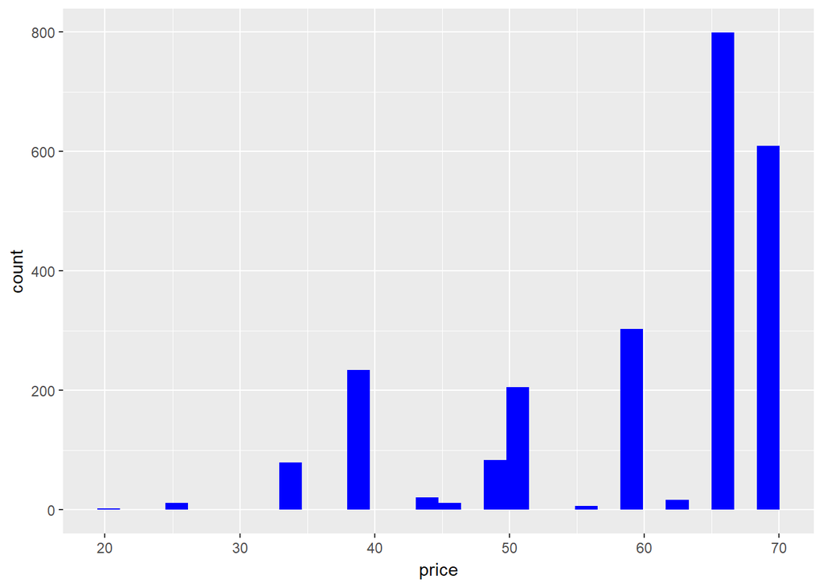

```r
ggplot(data=yo, aes(x=price)) + geom_histogram(fill= "blue")
```

### Number of Purchases

Notes:

```r
yo <- transform(yo, all.purchases = strawberry + blueberry + pina.colada + plain + mixed.berry)
```

### Prices over Time

Notes:

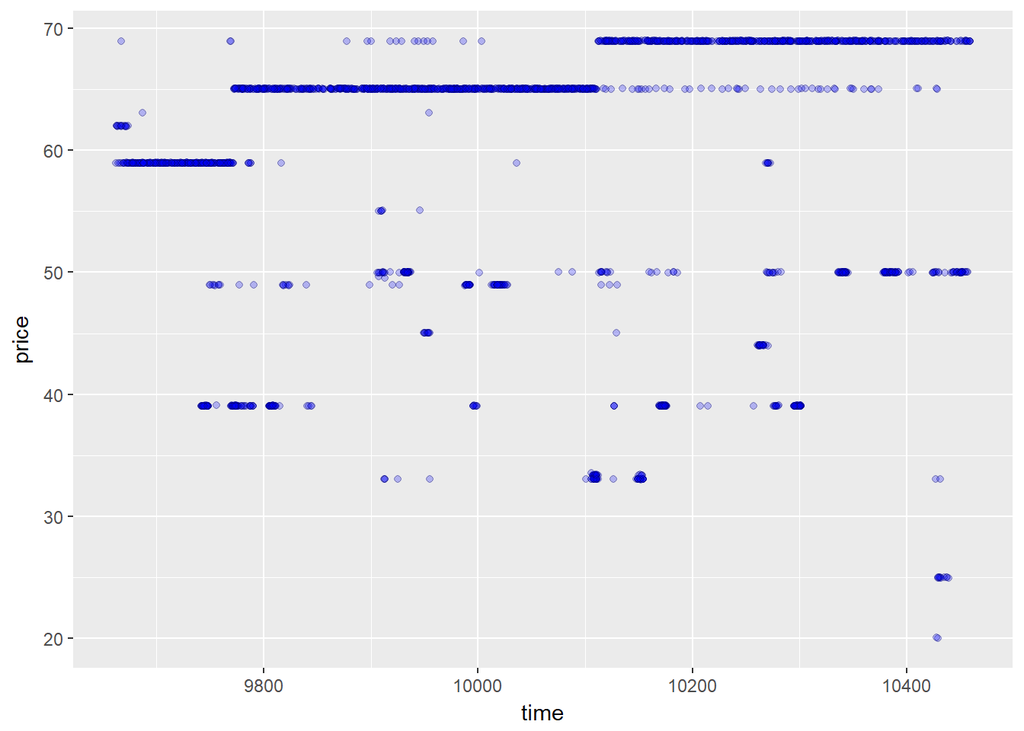

```r
ggplot(data=yo, aes(x=time, y=price)) +
  geom_jitter(alpha=.25, shape = 21, fill="blue")
```

### Sampling Observations

Notes: With so many repeat measurements it is useful to take a random subset of the data (in this case purchases for a household), to be able to more closely examine variation across data points (households). ***

### Looking at Samples of Households

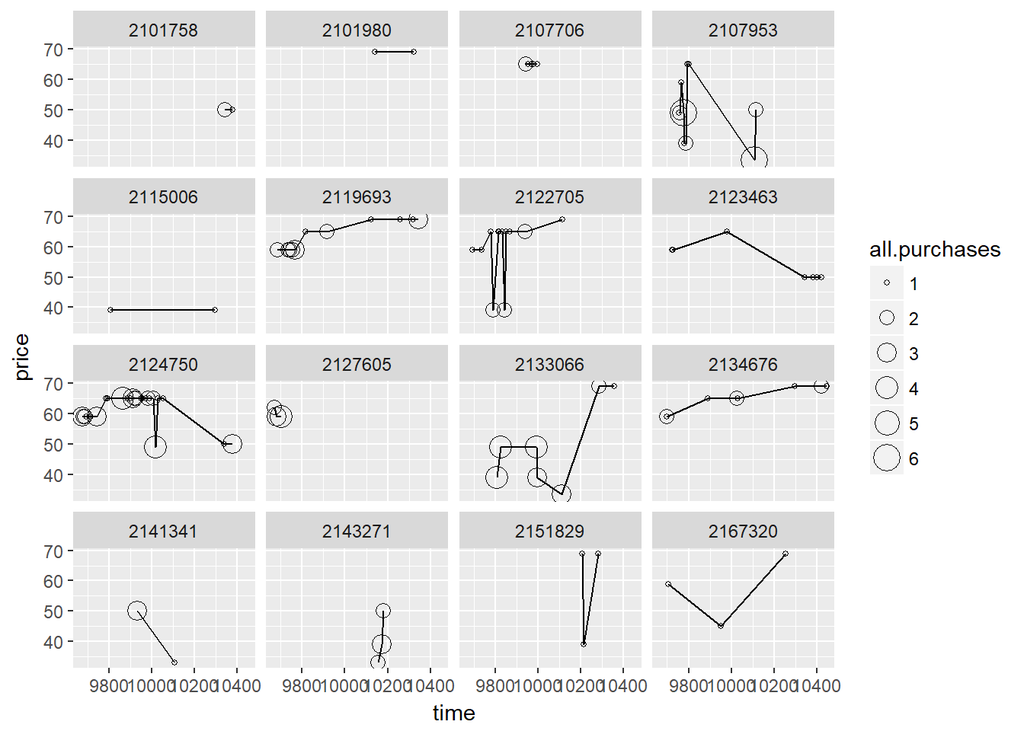

```r
set.seed(4230)
samp.ids <- sample(levels(yo$id), 16)

ggplot(data=subset(yo, id %in% samp.ids),
       aes(x=time, y=price)) +
  facet_wrap(~id) +
  geom_line() +
  geom_point(aes(size = all.purchases), pch=1)
```

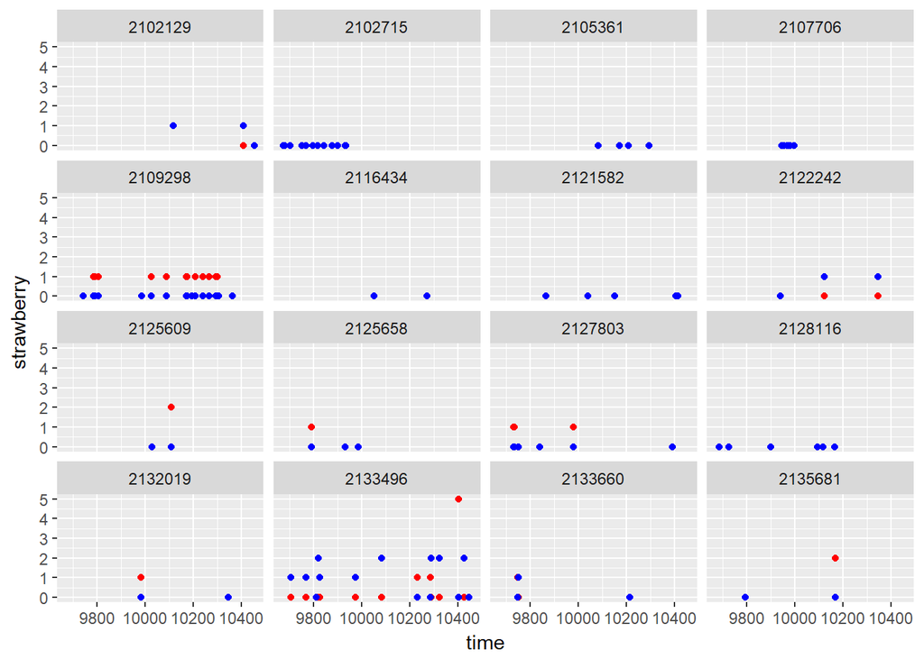

```r
set.seed(201)

samp.ids <- sample(levels(yo$id), 16)

ggplot(data=subset(yo, id %in% samp.ids), aes(x=time)) +
  facet_wrap(~id) +
  geom_point(aes(y=strawberry), color="red") +
  geom_point(aes(y=blueberry), color="blue")
```

### Many Variables

Notes:

### Scatterplot Matrix

Notes:

```r
library(GGally)
theme_set(theme_minimal(20))

set.seed(1836)
pf.subset <- pf[,c(2:15)]
names(pf.subset)
```

```
##  [1] "age"                   "dob_day"
##  [3] "dob_year"              "dob_month"
##  [5] "gender"                "tenure"
##  [7] "friend_count"          "friendships_initiated"
##  [9] "likes"                 "likes_received"
## [11] "mobile_likes"          "mobile_likes_received"
## [13] "www_likes"             "www_likes_received"
```

[figure not shown]

```r
ggpairs(pf.subset[sample.int(nrow(pf.subset),1000), ])
```

### Even More Variables

Notes:

### Heat Maps

Notes:

```r
nci <- read.table("nci.tsv")
colnames(nci) <- c(1:64)
```

```r
nci.long.samp <- melt(as.matrix(nci[1:200,]))
names(nci.long.samp) <- c("gene", "case", "value")
head(nci.long.samp)
```

```
##   gene case  value
## 1    1    1  0.300
## 2    2    1  1.180
## 3    3    1  0.550
## 4    4    1  1.140
## 5    5    1 -0.265
## 6    6    1 -0.070
```

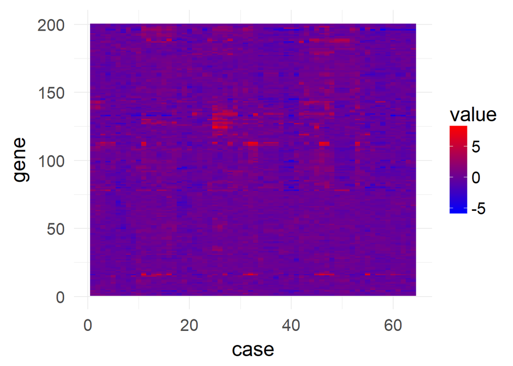

```r
ggplot(aes(y = gene, x = case, fill = value),
  data = nci.long.samp) +
  geom_tile() +
  scale_fill_gradientn(colours = colorRampPalette(c("blue", "red"))(100))
```

### Analyzing Three of More Variables

Reflection:

Click **KnitHTML** to see all of your hard work and to have an html page of this lesson, your answers, and your notes!